# Analyzing the Effect of External Factors on Crimes Reported in Boston

CMSC 320 Final Project

Pranav Kulkarni

## 1. Introduction

The ability to successfully analyze crime data is important to any major city and as cities expand, the need to accurately analyze crime data grows too — this is where data science steps in. Good data science techniques can be used to analyze hundreds of thousands of data points to find trends that will help city officials better allocate resources to curb crime rates. It can be used to find simple trends between time, day, and the crimes reported to be able to also model crime.

Therefore, for the final project of CMSC 320, **I have decided to analyze the effect of external factors like location of police stations, universities, and weather on the crimes reported in the Greater Boston area.**

For this analysis, I will use the *Crimes Reported in Boston* data set in addition to other data sets for police stations, universities, public schools, and the weather. I chose the Greater Boston area as the focus of my analysis because of their extensive open data hub, known as “Analyze Boston”. This enables any aspiring data scientist to access almost 160 extensive, accurate, and well-documented data sets.

### 1.1. Motivation

I first encountered the *Crimes Reported in Boston* data set two years ago while working on a group research project for the First-Year Innovation and Research Experience (FIRE) program. For that research project, my group and I analyzed *Crimes Reported in Boston* data set using our limited knowledge of CSV files, Excel, a little R, and some basic statistics. Although the project was very trivial, it inspired me to get into the data science field and further explore a potential career in it.

By revisiting the *Crimes Reported in Boston* data set after two years, my journey in the field of data science has come full circle. I want to apply the data science skills I have learned while taking CMSC 320 and my other experience in research to see how I have matured as a data scientist in the last two years at the University of Maryland.

*Before I begin my analysis, I would like to mention that this final project has no similarity with research project. It merely uses the same data set.*

## 2. Getting Started with the Data

In this section, we will get started with preparing our data for our analysis for the final project.

### 2.1. Required Libraries and Setup

We are going to mostly use the `tidyverse` package to simplify pipelines and data processing, in addition to other packages to help us visualize the data and conduct analysis.

```r
library(tidyverse)
library(lubridate)
library(broom)
library(leaflet)
```

### 2.2. Loading the Data

We are using open data hubs to access all the data sets we need. Since all of the data we need for the final project is available as CSV files, we will be using `read_csv()` to load all our data sets.

#### Crimes Reported in Boston

The data set contains all the necessary information about crimes reported from Boston Police offense codes, date/time of the crime, address, and coordinates of the location where a crime was reported.

```r
crimes <- read_csv('Crimes_Reported.csv') %>%
  drop_na(Lat, Long)
crimes
```

```
## # A tibble: 416,071 x 17
##    INCIDENT_NUMBER OFFENSE_CODE OFFENSE_CODE_GR~ OFFENSE_DESCRIP~ DISTRICT
##    <chr>           <chr>        <chr>            <chr>            <chr>
##  1 I192082859      00724        Auto Theft       AUTO THEFT       E18
##  2 I192082751      00724        Auto Theft       AUTO THEFT       E18
##  3 I192082680      00727        Auto Theft       AUTO THEFT - LE~ D14
##  4 I192082577      00724        Auto Theft       AUTO THEFT       D4
##  5 I192079582      00727        Auto Theft       AUTO THEFT - LE~ A15
##  6 I192078648      03114        Investigate Pro~ INVESTIGATE PRO~ B3
##  7 I192078647      03115        Investigate Per~ INVESTIGATE PER~ A1
##  8 I192078645      01402        Vandalism        VANDALISM        B3
##  9 I192078645      03301        Verbal Disputes  VERBAL DISPUTE   B3
## 10 I192078642      03820        Motor Vehicle A~ M/V ACCIDENT IN~ D4
## # ... with 416,061 more rows, and 12 more variables: REPORTING_AREA <dbl>,
## #   SHOOTING <chr>, OCCURRED_ON_DATE <dttm>, YEAR <dbl>, MONTH <dbl>,
## #   DAY_OF_WEEK <chr>, HOUR <dbl>, UCR_PART <chr>, STREET <chr>, Lat <dbl>,
## #   Long <dbl>, Location <chr>
```

#### Public Schools in Boston

The *Public Schools in Boston* data set contains all the public schools in the Greater Boston area. Since there are no coordinates specificed, we will have to conduct analysis for this data for an entire neighborhood in general, instead of specific areas. The data set can be found on: https://data.boston.gov/dataset/public-schools

```r
schools <- read_csv('Public_Schools.csv')
schools
```

```
## # A tibble: 131 x 18
##         X      Y OBJECTID_1 OBJECTID BLDG_ID BLDG_NAME ADDRESS CITY  ZIPCODE
##     <dbl>  <dbl>      <dbl>    <dbl>   <dbl> <chr>     <chr>   <chr> <chr>
##  1 7.90e5 2.97e6          1        1       1 Guild Bl~ 195 Le~ East~ 02128
##  2 7.83e5 2.96e6          2        2       3 Kennedy,~ 343 Sa~ East~ 02128
##  3 7.82e5 2.96e6          3        3       4 Otis Bldg 218 Ma~ East~ 02128
##  4 7.81e5 2.96e6          4        4       6 Odonnell~ 33 Tre~ East~ 02128
##  5 7.82e5 2.96e6          5        5       7 East Bos~ 86 Whi~ East~ 02128
##  6 7.80e5 2.96e6          6        6       8 Umana / ~ 312 Bo~ East~ 02128
##  7 7.82e5 2.96e6          7        7      10 East Bos~ 135 Go~ East~ 02128
##  8 7.82e5 2.96e6          8        8      11 Mckay Bl~ 122 Co~ East~ 02128
##  9 7.82e5 2.96e6          9        9      12 Adams Bl~ 165 We~ East~ 02128
## 10 7.76e5 2.96e6         10       10      13 Harvard-~ 50 Bun~ Char~ 02129
## # ... with 121 more rows, and 9 more variables: CSP_SCH_ID <dbl>, SCH_ID <dbl>,
## #   SCH_NAME <chr>, SCH_LABEL <chr>, SCH_TYPE <chr>, SHARED <chr>,
## #   COMPLEX <chr>, POINT_X <dbl>, POINT_Y <dbl>
```

#### Police Stations in Boston

The *Police Stations in Boston* data set lists all the police stations in the 12 districts of the Greater Boston area and the Boston Police Headquarters. Similar to the *Public Schools in Boston* data set, since we only have information about districts/neighborhoods, we will only conduct analysis for a district as a whole instead of individual police stations. The data set can be found on: https://data.boston.gov/dataset/boston-police-stations

```r
police <- read_csv('Boston_Police_Stations.csv')
police
```

```
## # A tibble: 13 x 15
##         X      Y OBJECTID BLDG_ID    BID ADDRESS POINT_X POINT_Y NAME
##     <dbl>  <dbl>    <dbl> <chr>    <dbl> <chr>     <dbl>   <dbl> <chr>
##  1 7.58e5 2.92e6        1 Bos_18~ 100639 1249 H~ 757883.  2.92e6 Dist~
##  2 7.51e5 2.93e6        2 Bos_20~ 112112 1708 C~ 751313.  2.93e6 Dist~
##  3 7.81e5 2.96e6        3 Bos_01~ 131503 69 Par~ 780828.  2.96e6 Dist~
##  4 7.75e5 2.96e6        4 Bos_03~ 136171 40 New~ 775000.  2.96e6 Dist~
##  5 7.51e5 2.95e6        5 Bos_22~ 145004 301 Wa~ 750622.  2.95e6 Dist~
##  6 7.76e5 2.96e6        6 Bos_02~ 148316 20 Vin~ 776124.  2.96e6 Dist~
##  7 7.76e5 2.95e6        7 Bos_06~ 154919 101 W ~ 776491.  2.95e6 Dist~
##  8 7.73e5 2.95e6        8 Bos_08~ 162100 650 Ha~ 772627.  2.95e6 Dist~
##  9 7.67e5 2.95e6        9 Bos_09~ 163892 One Sc~ 766822.  2.95e6 Bost~
## 10 7.68e5 2.94e6       10 Bos_12~ 176508 2400 W~ 768201.  2.94e6 Dist~
## 11 7.63e5 2.94e6       11 Bos_11~ 180965 3345 W~ 763107.  2.94e6 Dist~
## 12 7.67e5 2.93e6       12 Bos_14~ 186089 1165 B~ 766650.  2.93e6 Dist~
## 13 7.75e5 2.93e6       13 Bos_16~ 189445 40 Gib~ 775429.  2.93e6 Dist~
## # ... with 6 more variables: NEIGHBORHOOD <chr>, CITY <chr>, ZIP <chr>,
## #   FT_SQFT <dbl>, STORY_HT <dbl>, PARCEL_ID <chr>
```

#### Weather Data for Boston

The *Weather Data for Boston* data set from NOAA contains weather data from the beginning of 2015 to date i.e 18th May 2020. It includes information about precipitation, snow, and the daily high and low temperature. The goal is to use this data set to find a correlation between severe weather conditions and crimes reported. The data set can be found on: https://www.ncdc.noaa.gov/cdo-web/datasets/GHCND/stations/GHCND:USW00014739/detail

```r
weather <- read_csv('Weather.csv')
weather
```

```
## # A tibble: 1,960 x 7
##    STATION     DATE       PRCP  SNOW  TAVG  TMAX  TMIN
##    <chr>       <chr>     <dbl> <dbl> <dbl> <dbl> <dbl>
##  1 USW00014739 1/1/2015  0       0      26    33    22
##  2 USW00014739 1/2/2015  0       0      34    41    31
##  3 USW00014739 1/3/2015  0.62    1.4    28    37    22
##  4 USW00014739 1/4/2015  0.570   0      38    52    35
##  5 USW00014739 1/5/2015  0       0      40    50    17
##  6 USW00014739 1/6/2015  0.02    0.2    17    18    15
##  7 USW00014739 1/7/2015  0       0      19    26     4
##  8 USW00014739 1/8/2015  0       0       8    19    -1
##  9 USW00014739 1/9/2015  0.01    0.2    23    30    19
## 10 USW00014739 1/10/2015 0       0      22    24    17
## # ... with 1,950 more rows
```

### 2.3. Tidying the Data

Now that we have all the data sets we intend to use in my analysis, we will now tidy all these data sets so we can easily use them for our analysis purposes.

#### Crimes Reported in Boston

To tidy the *Crimes Reported in Boston* data set, we strip down the data set to the important information only and remove redundancies that were created to simplify the data set such as `Location`, etc. We also mutate the `SHOOTING` attribute to show either 1 if there was a shooting or 0 if there was not. We are still keeping some information such as `OFFENSE_CODE_GROUP` and `STREET` so we can use it to visualize the crimes using the `leaflet` library.

```r
crimes_tidy <- crimes %>%
  mutate(OFFENSE_CODE = as.double(OFFENSE_CODE)) %>%
  mutate(SHOOTING = ifelse(is.na(SHOOTING), 0, 1)) %>%
  mutate(DATE = date(OCCURRED_ON_DATE))
crimes_tidy$Location <- NULL
crimes_tidy$UCR_PART <- NULL
crimes_tidy$REPORTING_AREA <- NULL
crimes_tidy$OFFENSE_DESCRIPTION <- NULL
crimes_tidy$YEAR <- NULL
crimes_tidy$MONTH <- NULL
crimes_tidy$HOUR <- NULL
crimes_tidy$INCIDENT_NUMBER <- NULL

crimes_tidy
```

```
## # A tibble: 416,071 x 10
##    OFFENSE_CODE OFFENSE_CODE_GR~ DISTRICT SHOOTING OCCURRED_ON_DATE
##           <dbl> <chr>            <chr>       <dbl> <dttm>
##  1          724 Auto Theft       E18             0 2019-10-13 09:28:24
##  2          724 Auto Theft       E18             0 2019-10-12 20:11:26
##  3          727 Auto Theft       D14             0 2019-10-12 15:12:43
##  4          724 Auto Theft       D4              0 2019-10-12 04:41:52
##  5          727 Auto Theft       A15             0 2019-10-02 08:08:49
##  6         3114 Investigate Pro~ B3              0 2019-09-29 06:39:00
##  7         3115 Investigate Per~ A1              0 2019-09-29 03:45:00
##  8         1402 Vandalism        B3              0 2019-09-29 06:00:00
##  9         3301 Verbal Disputes  B3              0 2019-09-29 06:00:00
## 10         3820 Motor Vehicle A~ D4              0 2019-09-29 05:50:00
## # ... with 416,061 more rows, and 5 more variables: DAY_OF_WEEK <chr>,
## #   STREET <chr>, Lat <dbl>, Long <dbl>, DATE <date>
```

#### Weather in Boston

```r
weather_tidy <- weather %>%
  mutate(DATE = mdy(DATE)) %>%
  mutate(SEVERE = ifelse(PRCP > 1 | SNOW > 2, "Yes", "No"))

weather_tidy
```

```
## # A tibble: 1,960 x 8
##    STATION     DATE        PRCP  SNOW  TAVG  TMAX  TMIN SEVERE
##    <chr>       <date>     <dbl> <dbl> <dbl> <dbl> <dbl> <chr>
##  1 USW00014739 2015-01-01 0       0      26    33    22 No
##  2 USW00014739 2015-01-02 0       0      34    41    31 No
##  3 USW00014739 2015-01-03 0.62    1.4    28    37    22 No
##  4 USW00014739 2015-01-04 0.570   0      38    52    35 No
##  5 USW00014739 2015-01-05 0       0      40    50    17 No
##  6 USW00014739 2015-01-06 0.02    0.2    17    18    15 No
##  7 USW00014739 2015-01-07 0       0      19    26     4 No
##  8 USW00014739 2015-01-08 0       0       8    19    -1 No
##  9 USW00014739 2015-01-09 0.01    0.2    23    30    19 No
## 10 USW00014739 2015-01-10 0       0      22    24    17 No
## # ... with 1,950 more rows
```

### 3. Visualization of Crimes Reported in Boston

In this section, we will use the `leaflet` library to visualize all the crimes reported in Boston in September 2019. The markers will also be encoded with whether a shooting took place or not. Blue markers indicate a shooting was reported with the crime while red indicates no shooting occurred.

```r
popup <- "<b>%s %s</b><br/>%s<br/>%s"

crimes_tidy %>%
  filter(year(OCCURRED_ON_DATE) == 2019 & month(OCCURRED_ON_DATE) == 9) %>%
  leaflet() %>%
  addTiles() %>%
  setView(lat = 42.3, lng = -71.1, zoom = 11) %>%
  addCircleMarkers(~Long, ~Lat,
                   popup = ~sprintf(popup,
                                    OFFENSE_CODE,
                                    OFFENSE_CODE_GROUP,
                                    STREET,
                                    as.character(OCCURRED_ON_DATE)),
                   radius = 3,
                   color = "#000000",
                   fillColor = ~ifelse(SHOOTING, "#4974a5", "#ee3648"),
                   stroke = TRUE,
                   weight = 2,
                   fillOpacity = 1)
```

[interactive chart not shown]

### 4. Analysis of Crimes Reported in Boston

Now that our data has been prepared and is tidy, we will start analyzing the effect of our external factors on the crimes reported in the Greater Boston area.

#### 4.1. Effect of Severe Weather on Crime Reported

Then, we will plot a linear fit for our hypothesis that severe weather has effect on crimes reported. Then we will create a linear regression model to check whether our hypothesis is true.

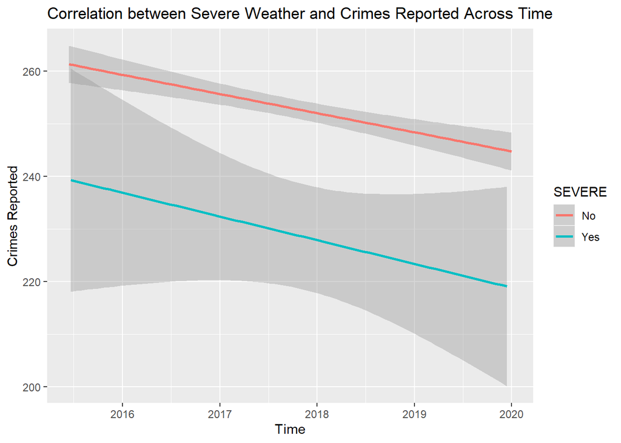

```r
crimes_total <- crimes_tidy %>%
  group_by(DATE) %>%
  tally(name = 'COUNT')

severe <- left_join(crimes_total, weather_tidy) %>%
  filter(year(DATE) <= 2019)

severe %>%
  ggplot(aes(x = DATE, y = COUNT, color = SEVERE)) +
  geom_smooth(method = lm) +
  labs(title = "Correlation between Severe Weather and Crimes Reported Across Time",
       x = "Time",
       y = "Crimes Reported")
```

```r
model <- lm(COUNT~SEVERE, data = severe) %>%
  tidy()
model
```

```
## # A tibble: 2 x 5
##   term        estimate std.error statistic      p.value
##   <chr>          <dbl>     <dbl>     <dbl>        <dbl>
## 1 (Intercept)    253.      0.922    275.   0
## 2 SEVEREYes      -24.7     4.38      -5.63 0.0000000216
```

In the plot, we can clearly see that severe weather has an effect on the crimes reported. Although our standard error is high, we are consistently showing that severe weather reduces crimes reported.

This is further proved by our linear regression model that has a p-value below our threshold of 0.05, suggesting a strong correlation between crimes reported and weather conditions.

#### 4.2. Effect of Education on Crimes Reported

The second external factor we are considering is whether an area with more public schools and wide spread education has less crime than areas which are less educated.

```r
police_tidy <- police %>%
  select(NAME, NEIGHBORHOOD) %>%
  filter(NAME != "Boston Police Headquarters") %>%
  mutate(DISTRICT = gsub("-","",substr(NAME, 10, 12))) %>%
  mutate(CITY = NEIGHBORHOOD) %>%
  select(CITY, DISTRICT)

schools_count <- schools %>%
  group_by(CITY) %>%
  tally(name = "SCHOOLS_COUNT") %>%
  inner_join(police_tidy)

crimes_count <- crimes_tidy %>%
  group_by(DISTRICT) %>%
  tally(name = "CRIMES_COUNT")

df <- inner_join(schools_count, crimes_count, by = "DISTRICT") %>%
  select(DISTRICT, SCHOOLS_COUNT, CRIMES_COUNT)
df
```

```
## # A tibble: 8 x 3
##   DISTRICT SCHOOLS_COUNT CRIMES_COUNT
##   <chr>            <int>        <int>
## 1 A1                  15        44255
## 2 D4                  15        52167
## 3 A1                   4        44255
## 4 A7                  11        17121
## 5 B3                   6        48010
## 6 B2                  19        65705
## 7 C6                   6        30006
## 8 E5                   7        17957
```

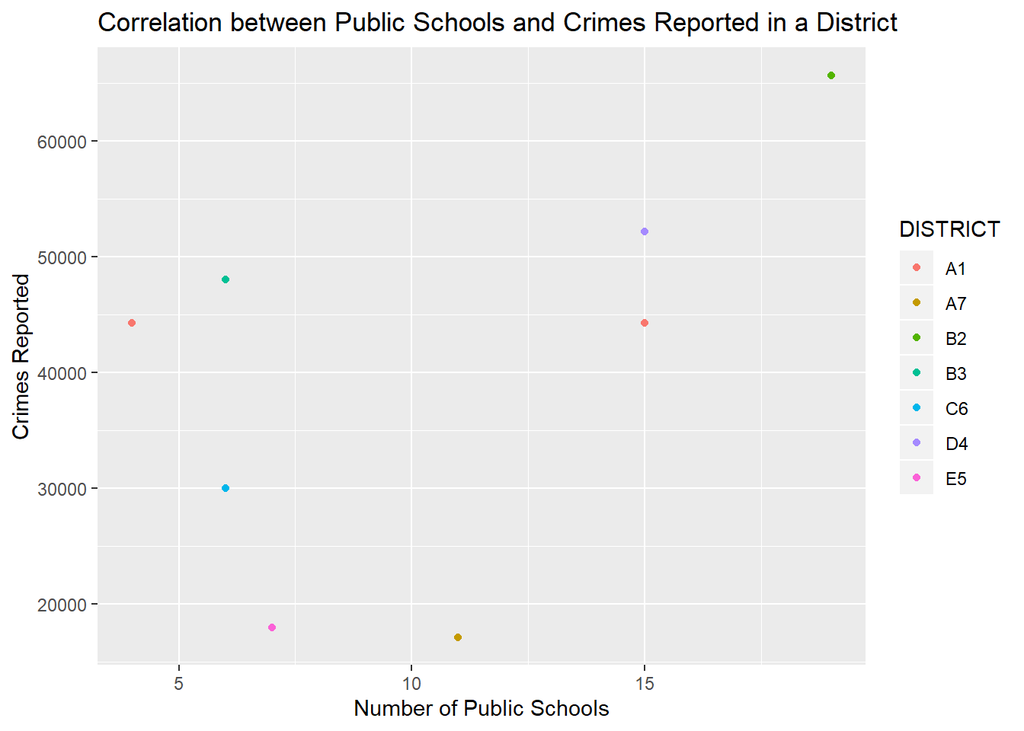

```r
df %>%
  ggplot(aes(x = SCHOOLS_COUNT, y = CRIMES_COUNT, color = DISTRICT)) +
  geom_point() +
  labs(title = "Correlation between Public Schools and Crimes Reported in a District",
       x = "Number of Public Schools",
       y = "Crimes Reported")
```

As you can see from the above graph, there is no direct correlation between number of public schools and the crimes reported. Some districts with the highest number of public schools have the highest crimes reported while the same result is seen in districts with lesser number of schools.